# #P4 EXPLORE AND SUMMARIZE DATA by Florina GEORGESCU

Instalation of packages requested and loading of its libraries

# Intro to the dataset

Datasets to be analized corresponds to a white wine samples of different variants of portuguese “Vinho Verde”. Inputs include objective tests (i.e. PH values) and the output is based on sensory data (median of at least 3 evaluations made by wine experts). Each expert graded the wine quality between 0 (very bad) and 10 (very excellent).

- Attribute information:psych

For more information, read [Cortez et al., 2009].

Input variables (based on physicochemical tests): 1 - fixed acidity (tartaric acid - g / dm^3) 2 - volatile acidity (acetic acid - g / dm^3) 3 - citric acid (g / dm^3) 4 - residual sugar (g / dm^3) 5 - chlorides (sodium chloride - g / dm^3 6 - free sulfur dioxide (mg / dm^3) 7 - total sulfur dioxide (mg / dm^3) 8 - density (g / cm^3) 9 - pH 10 - sulphates (potassium sulphate - g / dm3) 11 - alcohol (% by volume) Output variable (based on sensory data): 12 - quality (score between 0 and 10) # Missing Attribute Values: None

# Univariate Plots Section

I’m going to start looking to the distributions of the white wine dataset. For this I am going to visualize the histograms of the different variables of the file in order to check their distributions.

```
##        X        fixed.acidity    volatile.acidity  citric.acid
##  Min.   :   1   Min.   : 3.800   Min.   :0.0800   Min.   :0.0000
##  1st Qu.:1225   1st Qu.: 6.300   1st Qu.:0.2100   1st Qu.:0.2700
##  Median :2450   Median : 6.800   Median :0.2600   Median :0.3200
##  Mean   :2450   Mean   : 6.855   Mean   :0.2782   Mean   :0.3342
##  3rd Qu.:3674   3rd Qu.: 7.300   3rd Qu.:0.3200   3rd Qu.:0.3900
##  Max.   :4898   Max.   :14.200   Max.   :1.1000   Max.   :1.6600
##  residual.sugar     chlorides       free.sulfur.dioxide
##  Min.   : 0.600   Min.   :0.00900   Min.   :  2.00
##  1st Qu.: 1.700   1st Qu.:0.03600   1st Qu.: 23.00
##  Median : 5.200   Median :0.04300   Median : 34.00
##  Mean   : 6.391   Mean   :0.04577   Mean   : 35.31
##  3rd Qu.: 9.900   3rd Qu.:0.05000   3rd Qu.: 46.00
##  Max.   :65.800   Max.   :0.34600   Max.   :289.00
##  total.sulfur.dioxide    density             pH          sulphates
##  Min.   :  9.0        Min.   :0.9871   Min.   :2.720   Min.   :0.2200
##  1st Qu.:108.0        1st Qu.:0.9917   1st Qu.:3.090   1st Qu.:0.4100
##  Median :134.0        Median :0.9937   Median :3.180   Median :0.4700
##  Mean   :138.4        Mean   :0.9940   Mean   :3.188   Mean   :0.4898
##  3rd Qu.:167.0        3rd Qu.:0.9961   3rd Qu.:3.280   3rd Qu.:0.5500
##  Max.   :440.0        Max.   :1.0390   Max.   :3.820   Max.   :1.0800
##     alcohol         quality
##  Min.   : 8.00   Min.   :3.000
##  1st Qu.: 9.50   1st Qu.:5.000
##  Median :10.40   Median :6.000
##  Mean   :10.51   Mean   :5.878
##  3rd Qu.:11.40   3rd Qu.:6.000
##  Max.   :14.20   Max.   :9.000
```

```
## [1] 4898   13
```

```
##  [1] "X"                    "fixed.acidity"        "volatile.acidity"
##  [4] "citric.acid"          "residual.sugar"       "chlorides"
##  [7] "free.sulfur.dioxide"  "total.sulfur.dioxide" "density"
## [10] "pH"                   "sulphates"            "alcohol"
## [13] "quality"
```

```
## 'data.frame':    4898 obs. of  13 variables:
##  $ X                   : int  1 2 3 4 5 6 7 8 9 10 ...
##  $ fixed.acidity       : num  7 6.3 8.1 7.2 7.2 8.1 6.2 7 6.3 8.1 ...
##  $ volatile.acidity    : num  0.27 0.3 0.28 0.23 0.23 0.28 0.32 0.27 0.3 0.22 ...
##  $ citric.acid         : num  0.36 0.34 0.4 0.32 0.32 0.4 0.16 0.36 0.34 0.43 ...
##  $ residual.sugar      : num  20.7 1.6 6.9 8.5 8.5 6.9 7 20.7 1.6 1.5 ...
##  $ chlorides           : num  0.045 0.049 0.05 0.058 0.058 0.05 0.045 0.045 0.049 0.044 ...
##  $ free.sulfur.dioxide : num  45 14 30 47 47 30 30 45 14 28 ...
##  $ total.sulfur.dioxide: num  170 132 97 186 186 97 136 170 132 129 ...
##  $ density             : num  1.001 0.994 0.995 0.996 0.996 ...
##  $ pH                  : num  3 3.3 3.26 3.19 3.19 3.26 3.18 3 3.3 3.22 ...
##  $ sulphates           : num  0.45 0.49 0.44 0.4 0.4 0.44 0.47 0.45 0.49 0.45 ...
##  $ alcohol             : num  8.8 9.5 10.1 9.9 9.9 10.1 9.6 8.8 9.5 11 ...
##  $ quality             : int  6 6 6 6 6 6 6 6 6 6 ...
```

The file contains data from 4898 white wines with numerical data of 12 parameters and one qualitative aspect and one aditional column with the number of trails.

Part of the features have outliers that far from the 3rd quartile in their distributions ( e.g.: fixed acidity, volatile acidity, residual sugar, total sulfur).

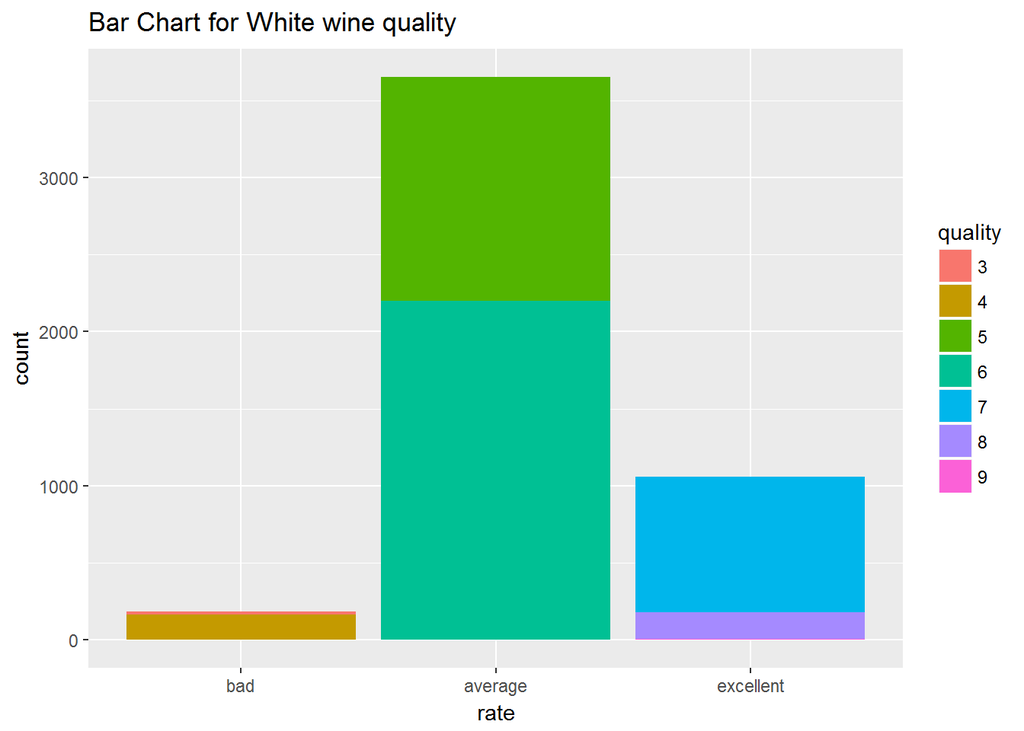

We can observe that most of the white wines in the list are considered as “average quality”.

Furtheron I will explore the data by creating histograms for each of the 12 variables (continous data).

To see them better I will group them togheter.

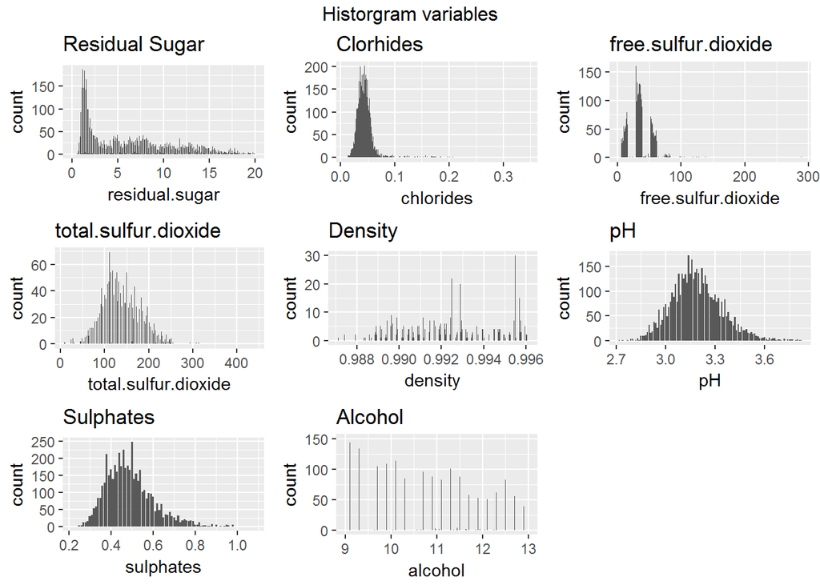

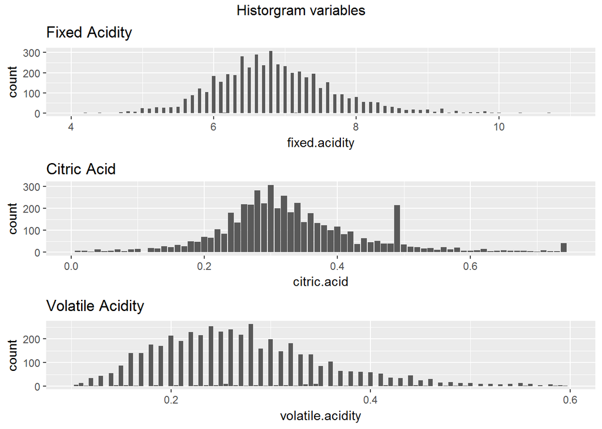

In general the distributions are skewed; probably because most of variables have outliers.

# Univariate Analysis

### What is the structure of your dataset?

The dataset is composed of 4898 registers of white wine. For each we have data 12 different characteristics or features of which one is a categorical variable - discrete (quality). From this variable I have created a new one clasyfing it into 3 categories according its rating. The remaining variables are physical and chemical properties e.g. %of alcohol pH, acidity, density, etc.

### What is/are the main feature(s) of interest in your dataset?

Quality is one of my main characteristic and the one that the consumer juges by a wine but, on the other hand, the perception of the quality of a wine is closely linked to its properties. As taste is one of the factors to take in acount I will look also at Residual sugar and Alcohol percentage.

### What other features in the dataset do you think will help support your investigation into your feature(s) of interest?

I will investigate the relationship between the quality with main physical/chemical characteristics (acidity, content of sugar, pH, alcohol). Density could have influence on the content of alcohol.

### Did you create any new variables from existing variables in the dataset?

I have created: - one new categorical variable called rate to classify the wines into 3 categories according to the quality value for each register.

### Of the features you investigated, were there any unusual distributions? Did you perform any operations on the data to tidy, adjust, or change the form of the data? If so, why did you do this?

If we look at the shapes of the histograms we see all having similar distributions except residual sugar and alcohol. The sacale is larger than normal due to points outside the boxplot (outliers).

# Bivariate Plots Section

First we install and load libraries to analise relation between variables.

I will create a panel to analise relationship between the different variables.

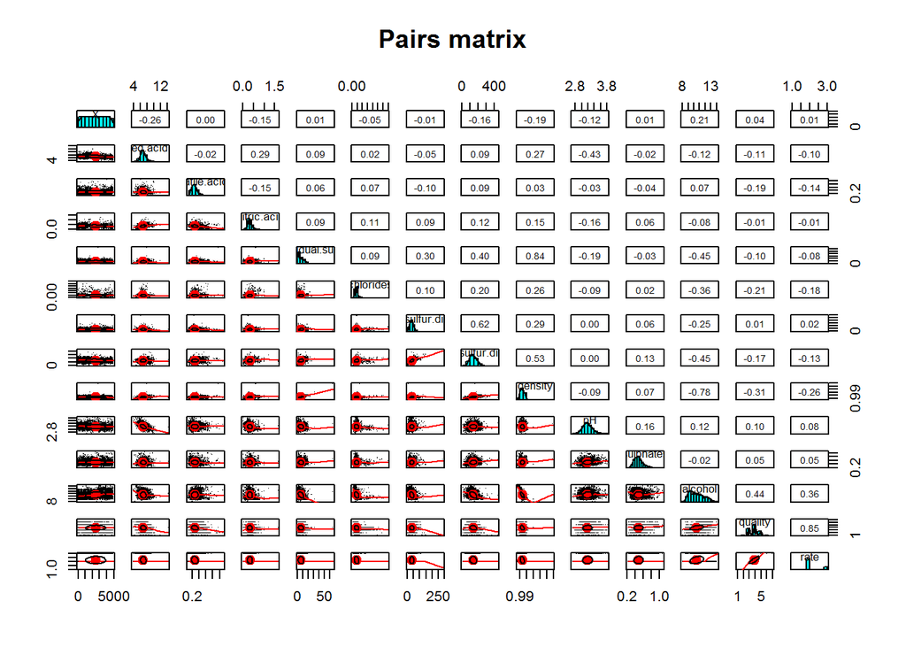

When ploting the panels in the console and examining it with a higher resolution in the Plot we can observe that the alghoritm works vey good as it shows a high correlation (0.85) between Quality and Rate, the two identical factors ( as you can remember rate has been created from quality). I have to try other plotting function as the correlation does not stand out from a visual perspective. Therefore I will use the corrplot in order to have in red and blue and with a higher font the correlations.

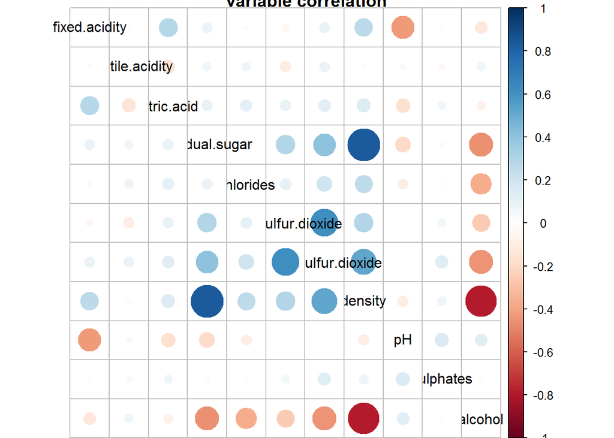

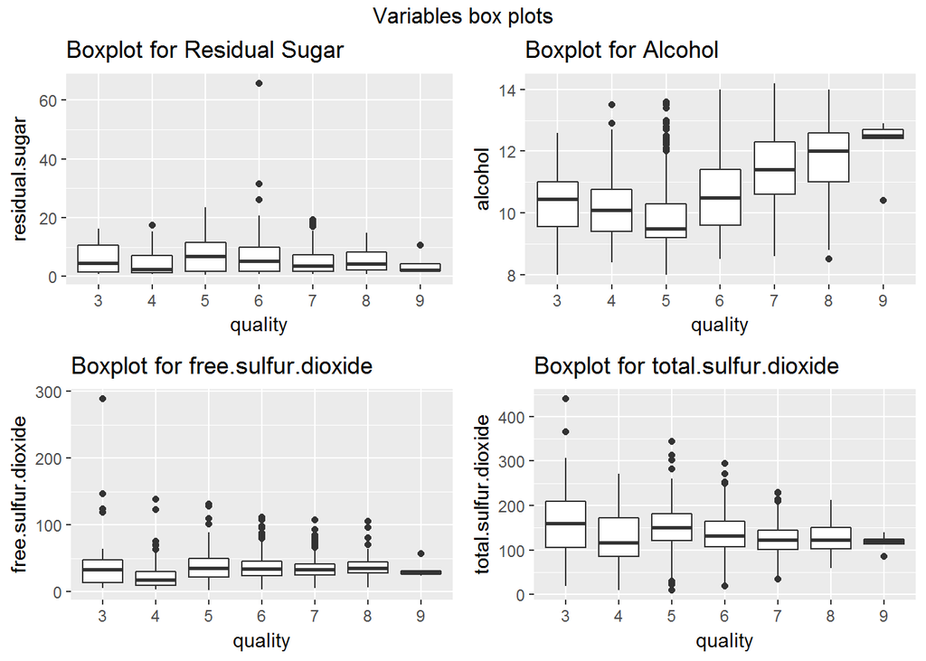

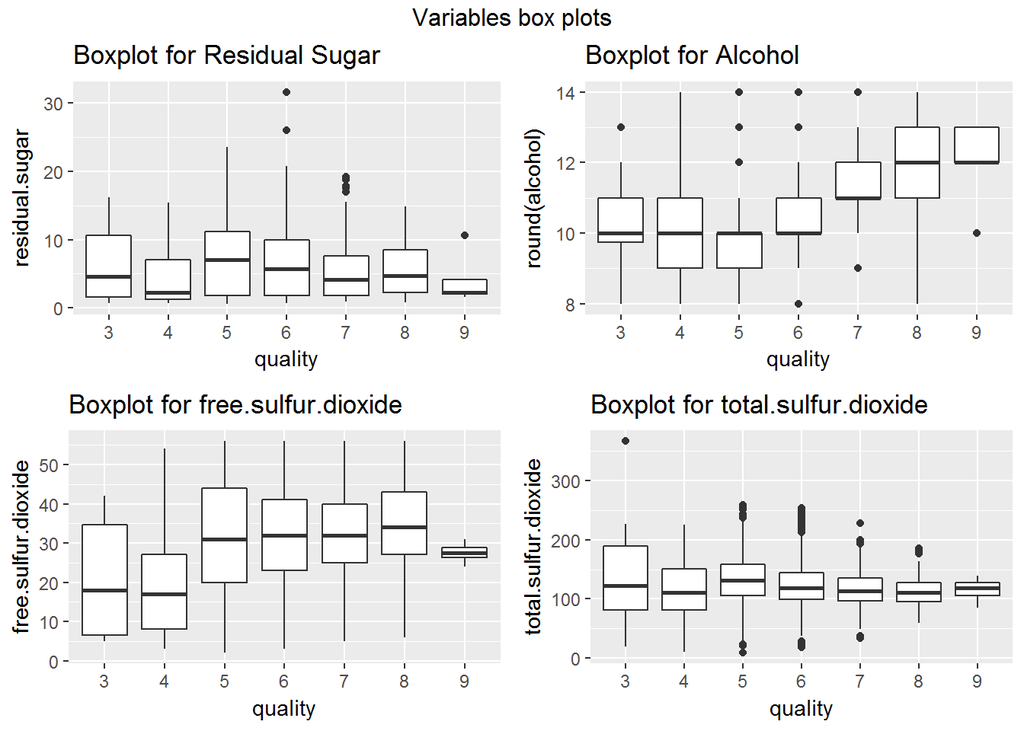

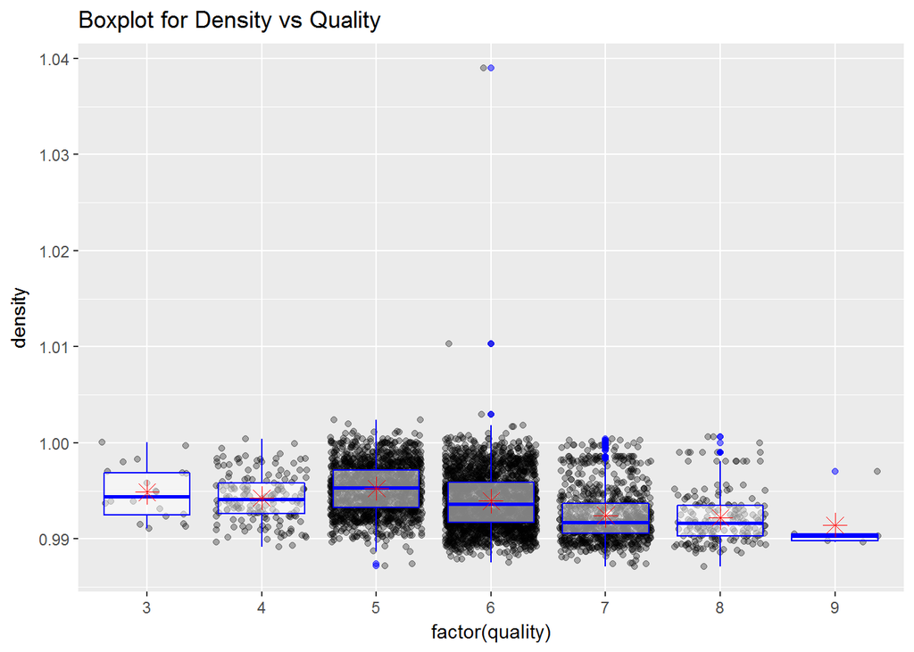

```
## # A tibble: 6 x 4
##   quality alcohol_mean alcohol_median     n
##     <ord>        <dbl>          <dbl> <int>
## 1       3     10.34500          10.45    20
## 2       4     10.15245          10.10   163
## 3       5      9.80884           9.50  1457
## 4       6     10.57537          10.50  2198
## 5       7     11.36794          11.40   880
## 6       8     11.63600          12.00   175
```

[output not shown]

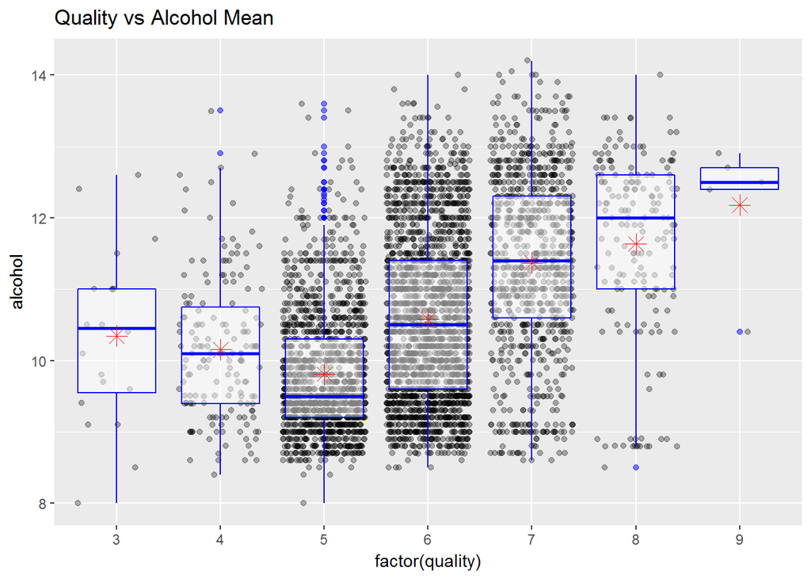

```
##
##  Pearson's product-moment correlation
##
## data:  alcohol and density
## t = -87.255, df = 4896, p-value < 2.2e-16
## alternative hypothesis: true correlation is not equal to 0
## 95 percent confidence interval:
##  -0.7908646 -0.7689315
## sample estimates:
##        cor
## -0.7801376
```

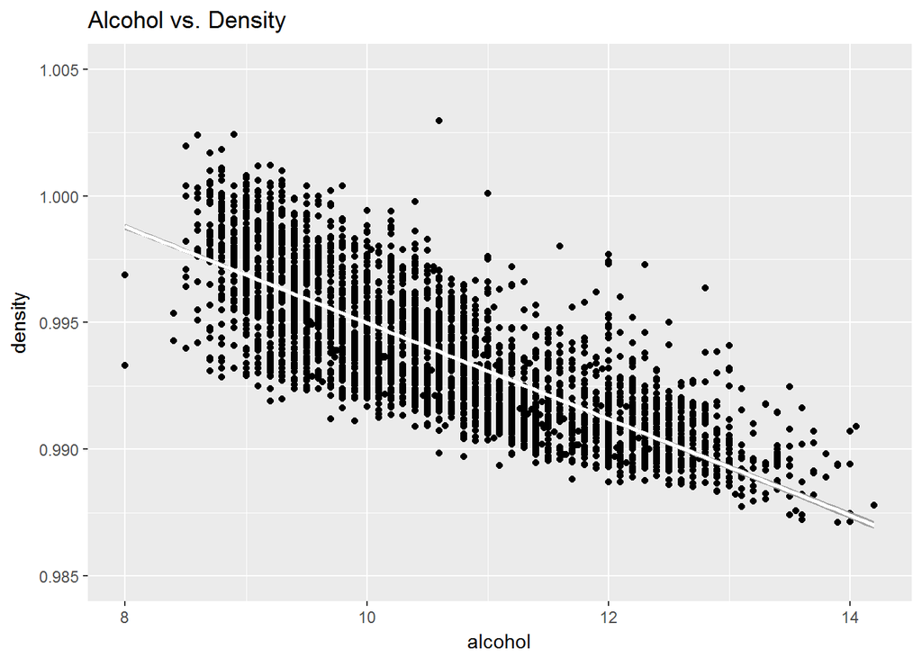

The other strong correlation is

```
##
##  Pearson's product-moment correlation
##
## data:  density and residual.sugar
## t = 107.87, df = 4896, p-value < 2.2e-16
## alternative hypothesis: true correlation is not equal to 0
## 95 percent confidence interval:
##  0.8304732 0.8470698
## sample estimates:
##       cor
## 0.8389665
```

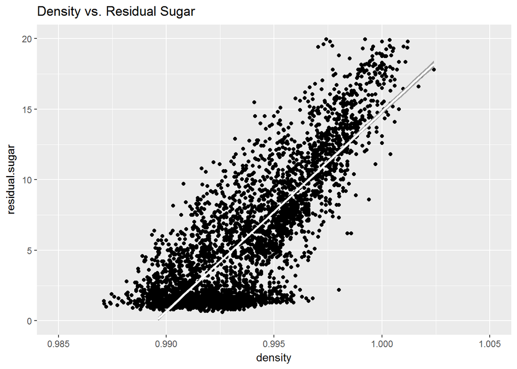

# Bivariate Analysis

### Talk about some of the relationships you observed in this part of the investigation. How did the feature(s) of interest vary with other features in the dataset?

Therefore it seems that a high quality white wine is high in alcohol, not sweet and not dense. Bare in mind as we haven’t conducted the experiment we can’t imply that the correlation is a causation. I am issuing my conclusion asuming here that the factors have been selected with a controlled experimient.

### Did you observe any interesting relationships between the other features (not the main feature(s) of interest)?

As observed in the correlation matrix, in general we can see that sulfur dioxide has an influence. Mantained in the median value provoques a evaluation with a higer quality grade.

### What was the strongest relationship you found?

The strongest relation (see pairs.panels) is given by the relation between variable rate and quality because we create the first one from the values of the second. Excluding this the next highest correlation is the positive correlation between residual sugar and density as can be seen in the graph corrplot and that I double checked with the Pearson correlation value (0,838).

# Multivariate Plots Section

Let’s focus on residual.sugar, alcohol and density relationship with Quality

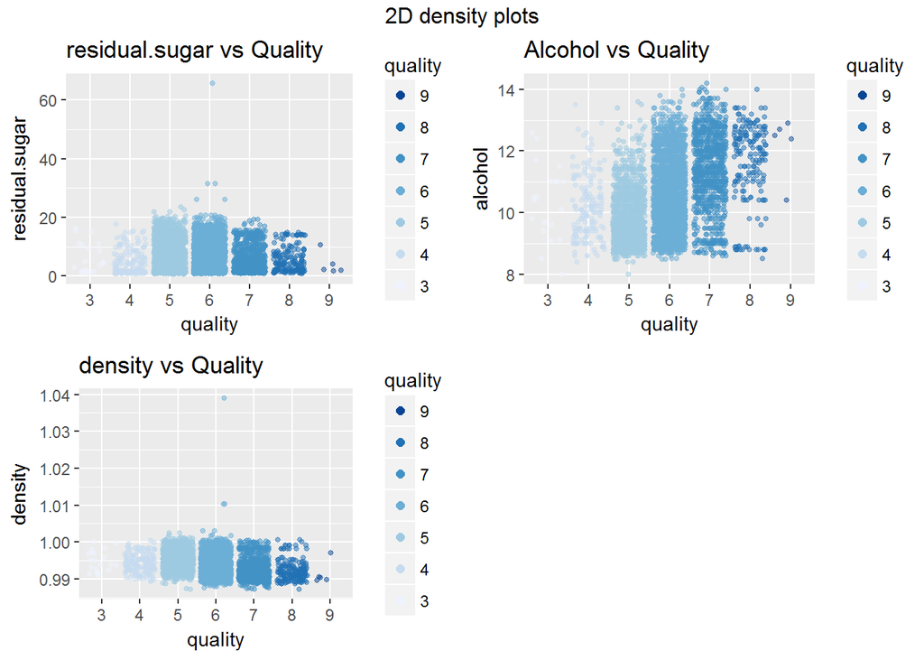

The dispersion plots confirms the hypotesis made before but we can observe that for Residual sugar and density we have a low sample tested. This can lead to error when making assumpltions and conclusions.

I am going to create a new dataframe just with the low and excellent qualities, to see clearly the patterns.

We have create a new dataframe just with 1243 observations instead 4898 but mantaining the same 14 variables.

I will perform same analysis with just the 3 parameters that seem to have more influence over quality: residual.sugar, alcohol, denisty.

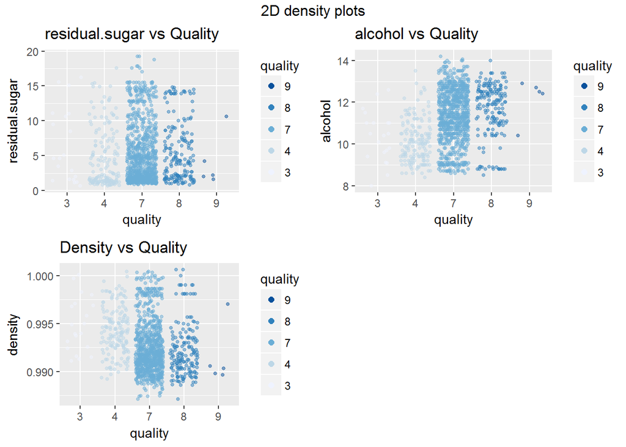

```
##
##  Pearson's product-moment correlation
##
## data:  residual.sugar and quality_lm
## t = -6.8603, df = 4896, p-value = 7.724e-12
## alternative hypothesis: true correlation is not equal to 0
## 95 percent confidence interval:
##  -0.12524103 -0.06976101
## sample estimates:
##         cor
## -0.09757683
```

```
##
##  Pearson's product-moment correlation
##
## data:  alcohol and quality_lm
## t = 33.858, df = 4896, p-value < 2.2e-16
## alternative hypothesis: true correlation is not equal to 0
## 95 percent confidence interval:
##  0.4126015 0.4579941
## sample estimates:
##       cor
## 0.4355747
```

```
##
##  Pearson's product-moment correlation
##
## data:  density and quality_lm
## t = -22.581, df = 4896, p-value < 2.2e-16
## alternative hypothesis: true correlation is not equal to 0
## 95 percent confidence interval:
##  -0.3322718 -0.2815385
## sample estimates:
##        cor
## -0.3071233
```

What we can observe is correlation between the factors but not related to the evaluated quality.

Even so, I want to create 2D visualization in order to cluster were Excellent and Bad wines are allocated in terms of the 3 parameters.I will create visualization with the different combination of the 3 characteristics

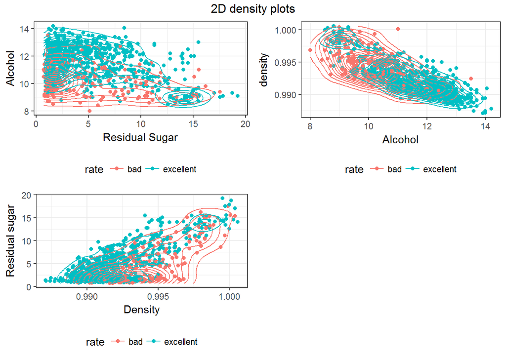

The density plot shows that the best and separated combination for the wine quality is alcohol and density.

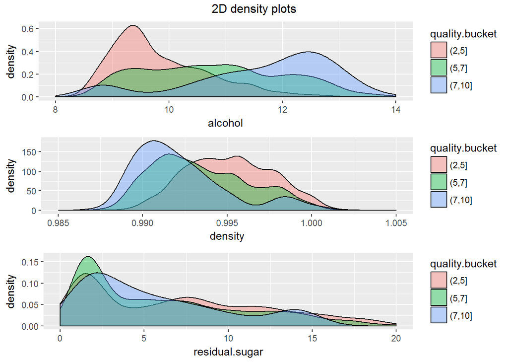

The graphics show no separation between the different buckets of quality for the 3 variables. Alcohol can be a good candidate to investigate further due to a partial separation.

With this patterns I will create linear models to see if I can relate quality with those 3 features.

```
##
## Calls:
## m1: lm(formula = I(quality_lm ~ residual.sugar), data = rw)
## m2: lm(formula = quality_lm ~ residual.sugar + alcohol, data = rw)
## m3: lm(formula = quality_lm ~ residual.sugar + alcohol + density,
##     data = rw)
##
## ====================================================
##                      m1         m2          m3
## ----------------------------------------------------
##   (Intercept)      5.987***   2.021***   90.313***
##                   (0.020)    (0.117)    (12.374)
##   residual.sugar  -0.017***   0.022***    0.053***
##                   (0.002)    (0.002)     (0.005)
##   alcohol                     0.354***    0.246***
##                              (0.010)     (0.018)
##   density                               -87.886***
##                                         (12.317)
## ----------------------------------------------------
##   R-squared            0.0        0.2        0.2
##   adj. R-squared       0.0        0.2        0.2
##   sigma                0.9        0.8        0.8
##   F                   47.1      619.4      434.1
##   p                    0.0        0.0        0.0
##   Log-likelihood   -6331.2    -5802.2    -5776.8
##   Deviance          3804.4     3065.3     3033.7
##   AIC              12668.4    11612.3    11563.6
##   BIC              12687.9    11638.3    11596.1
##   N                 4898       4898       4898
## ====================================================
```

First of all, we look for the goodness of our model, and it’s not good with values of R-square of 0 -0,2.

If we take a look to m-values, most important variable (whitin this low correlation) in the model m3 with all 3 factors combined.

# Multivariate Analysis

### Talk about some of the relationships you observed in this part of the investigation. Were there features that strengthened each other in terms of looking at your feature(s) of interest?

I started my multivariate study with the 3 vaiables that where corelated among eachother. The correlation was strong between them but when looking closer and making the 2D desnity plot we can’t observe a real separation between the 2 popularion ( bad and excelent wines). This is confirmed by the analysis made with 3 models including each of the features according to its correlation (Pearson method) with quality: residual.sugar, alcohol, density.

When I do data analysis for problem solving I use this technique: choose the best of the best register versus worst of the worst refisters. Sadly the investigation confirms that when using this technique there is no strong correlation between these 3 variables and the wine quality.

### Were there any interesting or surprising interactions between features?

The scatterplots do not show an interaction and when building the linear model we can observe that this is confirmed by the R squared and P value.

### OPTIONAL: Did you create any models with your dataset? Discuss the strengths and limitations of your model.

I have created 3 lineal models begining just with 1 feature as predictor and including in the next the an additional predictor according to its correlation with quality; so first model includes only residual.sugar, after I add alcohol, and then density also.

R-squawhite values is low (0,2) so, it will be difficult to adjust it to a model. The issue is the data that contains quality evaluation mainly for the average quality wines therefore makes it difficult to give a finding about the high quality wines.

# Final Plots and Summary

I have selected the following 3 plots

### Plot One

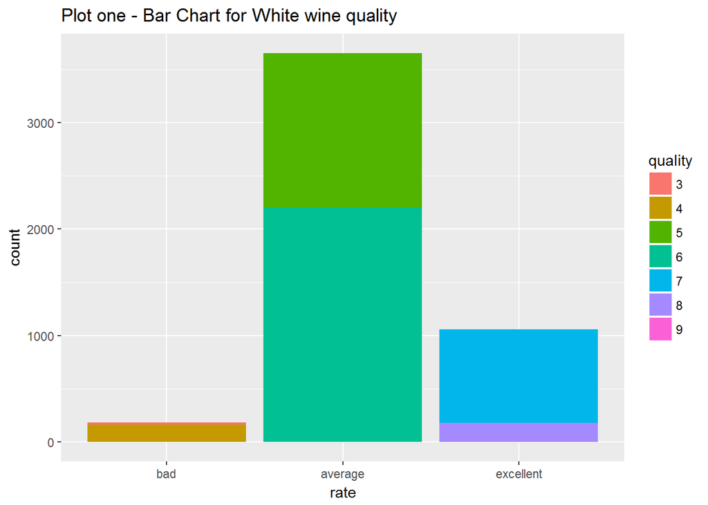

### Description One

This plot gives us an overview about the dataset.As we will discuss furtheron about the quality of the white wine we need to identify how large is aour data set and what is the range of the ratinngs provided for our data set.

This bar chart is the simplest grafic used but it lets us easily identify whit the colour palette that there considerably more average wines evaluated than bad or excelent.

### Plot Two

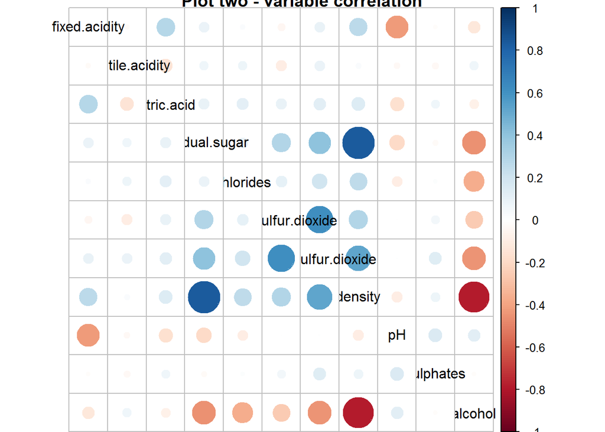

### Description Two

For the second plot I have selected the corrplot that gives us the correlation between variables. The colours offer us the perspective of easly identifying positive (blue) and negative (red) correlation. The size of the circles reflect the magnitude of the correlation, the higher the diameter of the circle highest the correlation.

### Plot Three

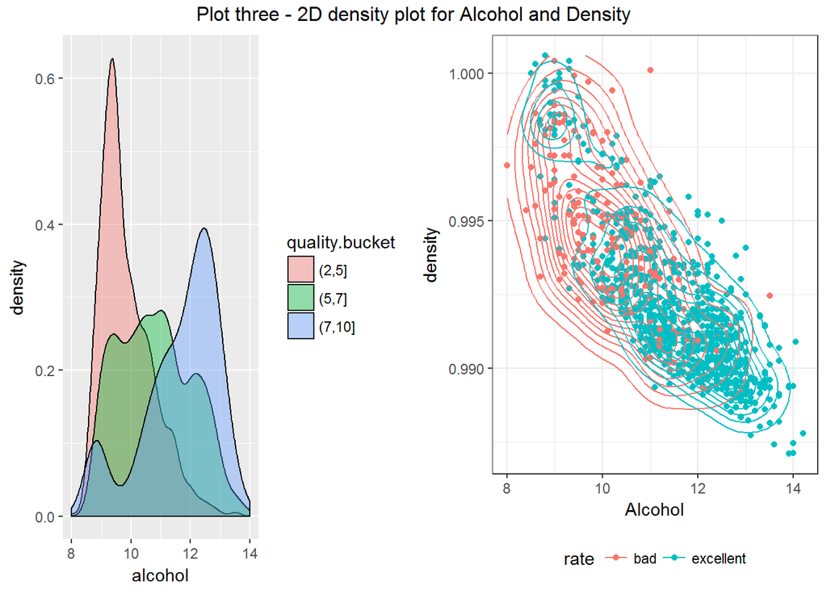

# Reflection

The correlation between the variables is strong, close to 1 (e.g.: residual sugar and density have a positive correlation of 0.84).

On the other hand I am surprised that the projects that i found on GitHub and treat the white wine data all refer to a correlation of the white wine variables (some of them) and the quality even though we can observe within the correlation plot with a low correlation with the final output.

Taking in account the correlation between those characteristics I have made a linear model that is not predicting very well because R-square value is just 0,2 but allows us to confirm the conclusion.

In order more reliable results we should have had a continuous feature for quality and therefore distinguish better between a wine with a 8.5 and one of 9. It will be interesting to make the same calculation with the cleaned dataset of what we identify with the boxplot as outliers and try with more complex models instead linear ones to analyze the relation between the 3 variables and the main output. For further investigation we will need more data for bad and excellent ones in order to be able to have a prediction algorithm ( this is one of the main reasons why I did not eliminate outliers).

I struggled to find a correlation between the variables provided and the quality of the wine but I did not find one, even when creating a linear model. I had issues at the begining with the packages installation untill I understood that is better to install them in the console and after just call the library. I consider myself successful in being able to learn how to explore the data in R and the different possibilities to visualize and summarize data provided. I discovered a software that is to my liking and more centered on the statistic part of exploring data and with surprisingly esthetic visualization. I love the way it publishes the data easily in html and it offers you also the free hosting.